# Business_Case_LoanTap_Logistic_Regression

### Step 1: Define the Problem Statement and Objectives

#### Problem Statement

LoanTap is building an underwriting layer to determine the creditworthiness of individuals applying for personal loans. The task is to analyze the dataset and build a predictive model to decide whether a credit line should be extended to an individual based on their attributes. Additionally, actionable recommendations are required for business decisions regarding repayment terms and model usage.

#### Objectives

1. **Understand the Data**: Perform exploratory data analysis (EDA) to identify patterns, relationships, and insights.
2. **Preprocessing and Feature Engineering**: Prepare the dataset by handling missing values, scaling features, and engineering new features as needed.
3. **Model Development**: Build a logistic regression model to predict the likelihood of default or repayment.
4. **Evaluation and Tradeoffs**: Evaluate the model using metrics like precision, recall, and ROC AUC to determine the best balance between detecting defaulters and avoiding false positives.
5. **Business Recommendations**: Provide actionable insights to improve the decision-making process in loan underwriting.

### Step 2: Data Importation and Initial Inspection

In this step, we will load the dataset, inspect its structure, and perform initial checks to understand the characteristics of the data.

#### Key Objectives:

1. Load the dataset and display the first few rows.
2. Check the shape of the dataset (number of rows and columns).
3. Identify missing values in each column.
4. Analyze the data types of each column.
5. Generate descriptive statistics for numerical and categorical columns.

The results of this step will help us understand the dataset's structure and prepare for further analysis.

```python
# Import necessary libraries
import pandas as pd
import matplotlib.pyplot as plt

# Load the dataset
file_path = 'logistic_regression.csv'  # Replace with the correct file path if necessary
data = pd.read_csv(file_path)
```

```python
# Display the first few rows of the dataset
print("First 5 rows of the dataset:")
display(data.head())
```

```
First 5 rows of the dataset:
```

|  | loan_amnt | term | int_rate | installment | grade | sub_grade | emp_title | emp_length | home_ownership | annual_inc | ... | open_acc | pub_rec | revol_bal | revol_util | total_acc | initial_list_status | application_type | mort_acc | pub_rec_bankruptcies | address |
| --- | --- | --- | --- | --- | --- | --- | --- | --- | --- | --- | --- | --- | --- | --- | --- | --- | --- | --- | --- | --- | --- |
| 0 | 10000.0 | 36 months | 11.44 | 329.48 | B | B4 | Marketing | 10+ years | RENT | 117000.0 | ... | 16.0 | 0.0 | 36369.0 | 41.8 | 25.0 | w | INDIVIDUAL | 0.0 | 0.0 | 0174 Michelle Gateway\r\nMendozaberg, OK 22690 |
| 1 | 8000.0 | 36 months | 11.99 | 265.68 | B | B5 | Credit analyst | 4 years | MORTGAGE | 65000.0 | ... | 17.0 | 0.0 | 20131.0 | 53.3 | 27.0 | f | INDIVIDUAL | 3.0 | 0.0 | 1076 Carney Fort Apt. 347\r\nLoganmouth, SD 05113 |
| 2 | 15600.0 | 36 months | 10.49 | 506.97 | B | B3 | Statistician | < 1 year | RENT | 43057.0 | ... | 13.0 | 0.0 | 11987.0 | 92.2 | 26.0 | f | INDIVIDUAL | 0.0 | 0.0 | 87025 Mark Dale Apt. 269\r\nNew Sabrina, WV 05113 |
| 3 | 7200.0 | 36 months | 6.49 | 220.65 | A | A2 | Client Advocate | 6 years | RENT | 54000.0 | ... | 6.0 | 0.0 | 5472.0 | 21.5 | 13.0 | f | INDIVIDUAL | 0.0 | 0.0 | 823 Reid Ford\r\nDelacruzside, MA 00813 |
| 4 | 24375.0 | 60 months | 17.27 | 609.33 | C | C5 | Destiny Management Inc. | 9 years | MORTGAGE | 55000.0 | ... | 13.0 | 0.0 | 24584.0 | 69.8 | 43.0 | f | INDIVIDUAL | 1.0 | 0.0 | 679 Luna Roads\r\nGreggshire, VA 11650 |

5 rows × 27 columns

```python
# Check the shape of the dataset
print(f"\nDataset contains {data.shape[0]} rows and {data.shape[1]} columns.")
```

```
Dataset contains 41364 rows and 27 columns.
```

```python
# Check for missing values
missing_values = data.isnull().sum()
print("\nMissing Values:")
print(missing_values)
```

```
Missing Values:
loan_amnt                  0
term                       0
int_rate                   0
installment                0
grade                      0
sub_grade                  0
emp_title               2364
emp_length              1900
home_ownership             0
annual_inc                 0
verification_status        0
issue_d                    0
loan_status                0
purpose                    0
title                    166
dti                        0
earliest_cr_line           0
open_acc                   0
pub_rec                    0
revol_bal                  0
revol_util                27
total_acc                  0
initial_list_status        0
application_type           0
mort_acc                3825
pub_rec_bankruptcies      54
address                    1
dtype: int64
```

```python
# Check data types
print("\nData Types:")
print(data.dtypes)
```

```
Data Types:
loan_amnt               float64
term                     object
int_rate                float64
installment             float64
grade                    object
sub_grade                object
emp_title                object
emp_length               object
home_ownership           object
annual_inc              float64
verification_status      object
issue_d                  object
loan_status              object
purpose                  object
title                    object
dti                     float64
earliest_cr_line         object
open_acc                float64
pub_rec                 float64
revol_bal               float64
revol_util              float64
total_acc               float64
initial_list_status      object
application_type         object
mort_acc                float64
pub_rec_bankruptcies    float64
address                  object
dtype: object
```

```python
# Display basic statistics for numerical columns
print("\nStatistical Summary (Numerical):")
display(data.describe())
```

```
Statistical Summary (Numerical):
```

|  | loan_amnt | int_rate | installment | annual_inc | dti | open_acc | pub_rec | revol_bal | revol_util | total_acc | mort_acc | pub_rec_bankruptcies |
| --- | --- | --- | --- | --- | --- | --- | --- | --- | --- | --- | --- | --- |
| count | 41364.000000 | 41364.000000 | 41364.000000 | 4.136400e+04 | 41364.000000 | 41364.000000 | 41364.000000 | 41364.000000 | 41337.000000 | 41364.000000 | 37539.000000 | 41310.000000 |
| mean | 14120.261580 | 13.651636 | 431.998578 | 7.428202e+04 | 17.363288 | 11.309254 | 0.178609 | 15866.358403 | 53.864854 | 25.429576 | 1.805802 | 0.122150 |
| std | 8378.472648 | 4.462072 | 250.823082 | 5.947000e+04 | 8.200518 | 5.118044 | 0.511040 | 19690.335963 | 24.371407 | 11.844639 | 2.137853 | 0.358585 |
| min | 500.000000 | 5.320000 | 16.310000 | 2.500000e+03 | 0.000000 | 0.000000 | 0.000000 | 0.000000 | 0.000000 | 2.000000 | 0.000000 | 0.000000 |
| 25% | 8000.000000 | 10.490000 | 250.940000 | 4.500000e+04 | 11.280000 | 8.000000 | 0.000000 | 6043.750000 | 36.000000 | 17.000000 | 0.000000 | 0.000000 |
| 50% | 12000.000000 | 13.330000 | 376.190000 | 6.400000e+04 | 16.850000 | 10.000000 | 0.000000 | 11206.500000 | 55.000000 | 24.000000 | 1.000000 | 0.000000 |
| 75% | 20000.000000 | 16.550000 | 566.585000 | 9.000000e+04 | 22.950000 | 14.000000 | 0.000000 | 19618.250000 | 72.900000 | 32.000000 | 3.000000 | 0.000000 |
| max | 40000.000000 | 30.740000 | 1533.810000 | 6.100000e+06 | 189.900000 | 51.000000 | 11.000000 | 617838.000000 | 129.400000 | 111.000000 | 34.000000 | 6.000000 |

```python
# Display basic statistics for categorical columns
print("\nStatistical Summary (Categorical):")
display(data.describe(include=['object']))
```

```
Statistical Summary (Categorical):
```

|  | term | grade | sub_grade | emp_title | emp_length | home_ownership | verification_status | issue_d | loan_status | purpose | title | earliest_cr_line | initial_list_status | application_type | address |
| --- | --- | --- | --- | --- | --- | --- | --- | --- | --- | --- | --- | --- | --- | --- | --- |
| count | 41364 | 41364 | 41364 | 39000 | 39464 | 41364 | 41364 | 41364 | 41364 | 41364 | 41198 | 41364 | 41364 | 41364 | 41363 |
| unique | 2 | 7 | 35 | 24520 | 11 | 6 | 3 | 115 | 2 | 14 | 6995 | 583 | 2 | 3 | 41332 |
| top | 36 months | B | B3 | Manager | 10+ years | MORTGAGE | Verified | Oct-2014 | Fully Paid | debt_consolidation | Debt consolidation | Oct-2001 | f | INDIVIDUAL | USS Brown\r\nFPO AE 30723 |
| freq | 31545 | 12188 | 2817 | 473 | 13306 | 20625 | 14364 | 1569 | 33319 | 24490 | 16019 | 349 | 24788 | 41282 | 3 |

### Step 3: Handling Missing Values and Data Preprocessing

#### Objectives:

1. **Handle Missing Values**: Address missing values appropriately based on the nature of the data and business logic.
   - High missing columns like `emp_title`, `emp_length`, and `mort_acc` need careful handling or potential exclusion.
   - Low missing columns can be imputed with statistical methods (e.g., median or mode).
2. **Data Type Transformation**:
   - Convert categorical variables into a usable format for analysis and modeling.
   - Ensure all date columns (e.g., `issue_d`, `earliest_cr_line`) are properly formatted for feature extraction.
3. **Remove Unnecessary Columns**:
   - Drop columns like `address` that do not contribute to analysis or prediction.
4. **Document Changes**: Ensure all preprocessing steps are clearly documented for reproducibility.

#### Key Steps:

1. Drop unnecessary columns (`emp_title`, `address`) due to high cardinality or irrelevance.
2. Impute missing values for columns with low percentages of missing data:
   - **Median** for numerical columns (`revol_util`, `mort_acc`, `pub_rec_bankruptcies`).
   - **Mode** for categorical columns (`emp_length`, `title`).
3. Convert date columns (`issue_d`, `earliest_cr_line`) into useful numerical features like "months since."

```python
# Step 3: Handling Missing Values and Data Preprocessing

# Drop unnecessary columns
columns_to_drop = ['emp_title', 'address']
data = data.drop(columns=columns_to_drop, errors='ignore')

# Handle missing values
data['emp_length'] = data['emp_length'].fillna(data['emp_length'].mode()[0])  # Impute with mode
data['title'] = data['title'].fillna(data['title'].mode()[0])  # Impute with mode
data['revol_util'] = data['revol_util'].fillna(data['revol_util'].median())  # Impute with median
data['mort_acc'] = data['mort_acc'].fillna(data['mort_acc'].median())  # Impute with median
data['pub_rec_bankruptcies'] = data['pub_rec_bankruptcies'].fillna(data['pub_rec_bankruptcies'].median())  # Impute with median

# Convert 'term' column to numeric values
data['term'] = data['term'].str.extract('(\d+)').astype(float)

# Convert 'emp_length' column to numeric values
def convert_emp_length(emp_length):
    if emp_length == '< 1 year':
        return 0
    elif emp_length == '10+ years':
        return 10
    else:
        return float(emp_length.split()[0])

data['emp_length'] = data['emp_length'].apply(convert_emp_length)

# Convert date columns into numerical features
from datetime import datetime

def convert_to_months_since(date_column):
    return date_column.apply(lambda x: (datetime.now().year - datetime.strptime(x, '%b-%Y').year) * 12 +
                             (datetime.now().month - datetime.strptime(x, '%b-%Y').month))

data['issue_d_months_since'] = convert_to_months_since(data['issue_d'])
data['earliest_cr_line_months_since'] = convert_to_months_since(data['earliest_cr_line'])

# Drop original date columns
data = data.drop(columns=['issue_d', 'earliest_cr_line'], errors='ignore')

# Verify remaining missing values
print("Remaining Missing Values:")
print(data.isnull().sum())
```

```
Remaining Missing Values:
loan_amnt                        0
term                             0
int_rate                         0
installment                      0
grade                            0
sub_grade                        0
emp_length                       0
home_ownership                   0
annual_inc                       0
verification_status              0
loan_status                      0
purpose                          0
title                            0
dti                              0
open_acc                         0
pub_rec                          0
revol_bal                        0
revol_util                       0
total_acc                        0
initial_list_status              0
application_type                 0
mort_acc                         0
pub_rec_bankruptcies             0
issue_d_months_since             0
earliest_cr_line_months_since    0
dtype: int64
```

### Insights After Handling Missing Values

1. **Dataset Status**:
   - **Remaining Missing Values**: All missing values have been successfully handled, as confirmed by the result.
   - **Key Changes**:
     - Columns like `emp_title` and `address` were dropped due to high cardinality or irrelevance.
     - Missing values in numerical columns (`revol_util`, `mort_acc`, `pub_rec_bankruptcies`) were imputed with their median values.
     - Missing values in categorical columns (`emp_length`, `title`) were imputed with their mode.
     - Date columns (`issue_d`, `earliest_cr_line`) were transformed into numerical features (`issue_d_months_since`, `earliest_cr_line_months_since`).
2. **Prepared Dataset**:
   - The dataset is now free of missing values and ready for further analysis or feature engineering.

### Next Step: Exploratory Data Analysis (EDA)

#### Objective:

1. **Understand Relationships**: Analyze how different features relate to the target variable (`loan_status`).
2. **Visualizations**:
   - Distribution of key features (e.g., `loan_amnt`, `int_rate`) grouped by `loan_status`.
   - Relationship between categorical variables (`grade`, `purpose`, etc.) and `loan_status`.
3. **Feature Insights**:
   - Identify which features have a strong correlation or significant impact on the target variable.
4. **Prepare Data**: Refine features based on insights from EDA for model building.

#### Key Tasks:

1. Generate univariate plots to understand the distribution of features.
2. Perform bivariate analysis to explore relationships with the target variable.
3. Summarize insights to determine impactful features.

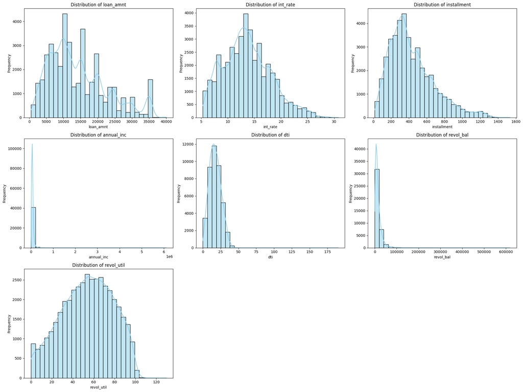

```python
import matplotlib.pyplot as plt
import seaborn as sns

# List of continuous variables
continuous_vars = ['loan_amnt', 'int_rate', 'installment', 'annual_inc', 'dti', 'revol_bal', 'revol_util']

# Set up the layout for subplots
plt.figure(figsize=(20, 15))
for i, column in enumerate(continuous_vars, 1):
    plt.subplot(3, 3, i)
    sns.histplot(data[column], kde=True, bins=30, color='skyblue')
    plt.title(f'Distribution of {column}')
    plt.xlabel(column)
    plt.ylabel('Frequency')

plt.tight_layout()
plt.show()
```

# Insights from Continuous Variables Distribution

# Step 5: Analyze Categorical Variables

### Objective:

To understand the distribution of categorical variables and their relationship with the target variable.

### Key Tasks:

1. Visualize the distribution of key categorical features such as `grade`, `sub_grade`, `home_ownership`, `verification_status`, and `purpose`.
2. Gain insights into how these features may influence the target variable (`loan_status`).
3. Use bar plots to highlight the counts of each category.

### Expected Outcome:

- Understand which categories dominate each feature.
- Observe any imbalances in the data distribution for categorical features.
- Identify potential feature transformations or aggregations for modeling.

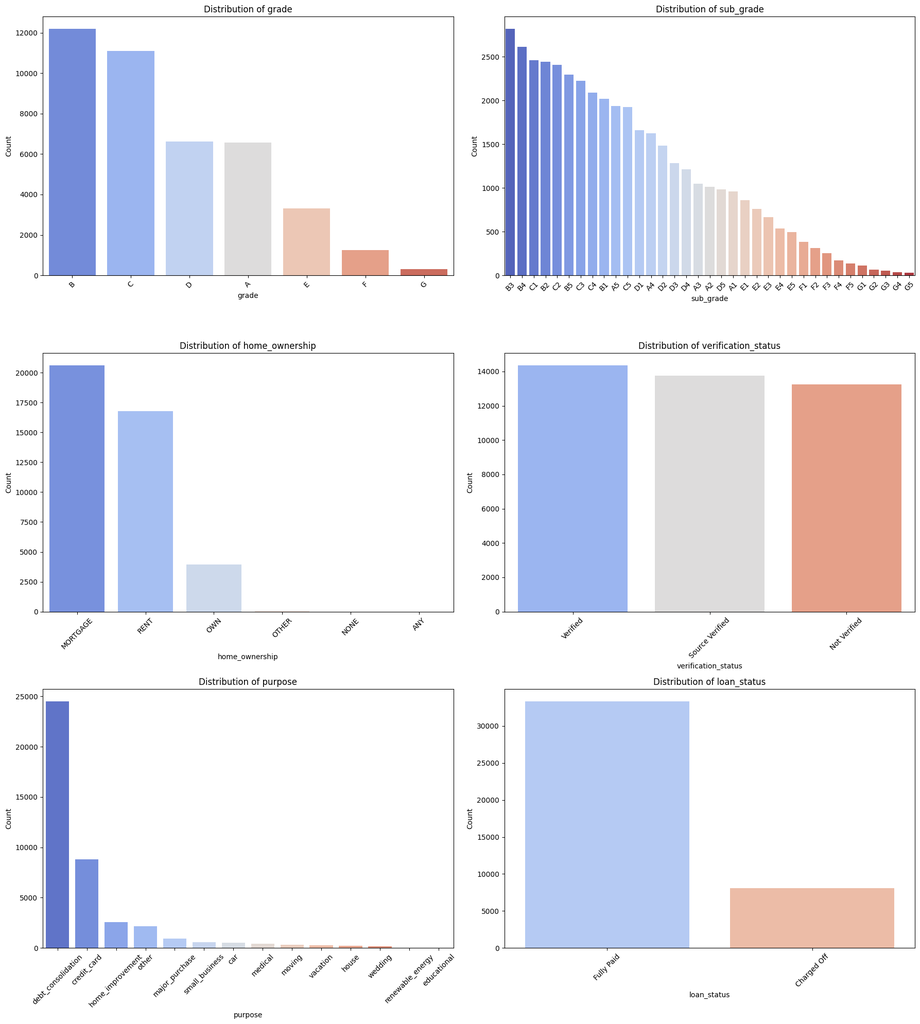

```python
# List of categorical variables to analyze
categorical_vars = ['grade', 'sub_grade', 'home_ownership', 'verification_status', 'purpose', 'loan_status']

# Set up the grid
plt.figure(figsize=(18, 20))
for i, var in enumerate(categorical_vars, 1):
    plt.subplot(3, 2, i)  # Adjust grid dimensions based on the number of variables
    sns.countplot(x=data[var], order=data[var].value_counts().index, palette="coolwarm")
    plt.title(f'Distribution of {var}')
    plt.xlabel(var)
    plt.ylabel('Count')
    plt.xticks(rotation=45)  # Rotate x-axis labels for better readability

plt.tight_layout()
plt.show()
```

### Insights from Categorical Variable Distributions

1. **Grade:**
   - Grades B and C dominate the dataset, indicating most loans are given to medium-credit borrowers.
   - Grades D, E, F, and G are significantly fewer, representing higher-risk loans.
2. **Sub-Grade:**
   - Sub-grades within B and C categories (e.g., B3, C3) are the most frequent.
   - As expected, sub-grades for higher-risk categories (e.g., F5, G5) are rare.
3. **Home Ownership:**
   - Borrowers with "MORTGAGE" and "RENT" dominate, suggesting that most borrowers do not own homes outright.
   - Very few borrowers fall into the "OWN" and "OTHER" categories.
4. **Verification Status:**
   - The distribution of income verification status is fairly balanced across "Verified," "Source Verified," and "Not Verified."
5. **Purpose:**
   - The most common loan purposes are "debt consolidation" and "credit card refinancing."
   - Other purposes like "small business," "vacation," and "home improvement" are less frequent.
6. **Loan Status:**
   - The dataset is imbalanced, with the majority of loans marked as "Fully Paid" and a smaller portion as "Charged Off."

### Step 6: Bivariate Analysis for Key Relationships

#### Objective:

To understand the relationships between the target variable (`loan_status`) and key predictors. This will help identify significant features for predicting loan status.

#### Key Tasks:

1. Explore how numerical variables (`loan_amnt`, `int_rate`, `installment`, etc.) differ across loan statuses.
2. Analyze the relationships between categorical variables (e.g., `grade`, `purpose`, `home_ownership`) and `loan_status`.
3. Generate visualizations such as box plots and count plots to interpret these relationships effectively.

#### Insights to Extract:

1. Which variables are strong indicators of whether a loan will be "Fully Paid" or "Charged Off"?
2. Are there any noticeable trends in numerical features across loan statuses?
3. Do certain categories in features like `grade` or `purpose` show higher default rates?

#### Approach:

1. Use box plots for numerical variables to observe their spread across loan statuses.
2. Use stacked bar plots or count plots for categorical variables to observe their distribution across loan statuses.

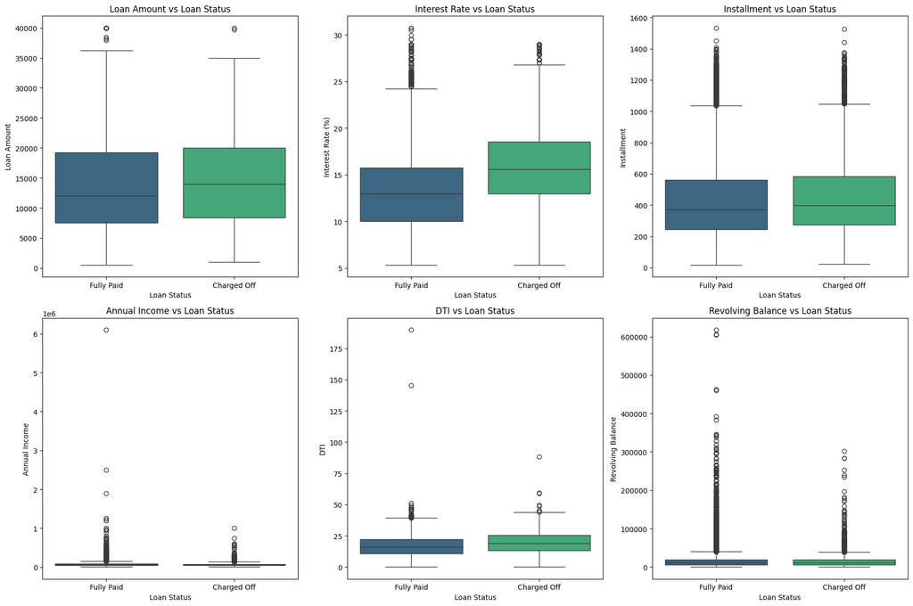

```python
# Import necessary library for visualizations
import seaborn as sns
import matplotlib.pyplot as plt

# Set up the layout for box plots
fig, axes = plt.subplots(2, 3, figsize=(18, 12))

# Loan Amount vs Loan Status
sns.boxplot(x='loan_status', y='loan_amnt', data=data, palette='viridis', ax=axes[0, 0])
axes[0, 0].set_title("Loan Amount vs Loan Status")
axes[0, 0].set_xlabel("Loan Status")
axes[0, 0].set_ylabel("Loan Amount")

# Interest Rate vs Loan Status
sns.boxplot(x='loan_status', y='int_rate', data=data, palette='viridis', ax=axes[0, 1])
axes[0, 1].set_title("Interest Rate vs Loan Status")
axes[0, 1].set_xlabel("Loan Status")
axes[0, 1].set_ylabel("Interest Rate (%)")

# Installment vs Loan Status
sns.boxplot(x='loan_status', y='installment', data=data, palette='viridis', ax=axes[0, 2])
axes[0, 2].set_title("Installment vs Loan Status")
axes[0, 2].set_xlabel("Loan Status")
axes[0, 2].set_ylabel("Installment")

# Annual Income vs Loan Status
sns.boxplot(x='loan_status', y='annual_inc', data=data, palette='viridis', ax=axes[1, 0])
axes[1, 0].set_title("Annual Income vs Loan Status")
axes[1, 0].set_xlabel("Loan Status")
axes[1, 0].set_ylabel("Annual Income")

# Debt-to-Income Ratio (DTI) vs Loan Status
sns.boxplot(x='loan_status', y='dti', data=data, palette='viridis', ax=axes[1, 1])
axes[1, 1].set_title("DTI vs Loan Status")
axes[1, 1].set_xlabel("Loan Status")
axes[1, 1].set_ylabel("DTI")

# Revolving Balance vs Loan Status
sns.boxplot(x='loan_status', y='revol_bal', data=data, palette='viridis', ax=axes[1, 2])
axes[1, 2].set_title("Revolving Balance vs Loan Status")
axes[1, 2].set_xlabel("Loan Status")
axes[1, 2].set_ylabel("Revolving Balance")

plt.tight_layout()
plt.show()
```

### Observations:

- Interest rate appears to be a strong differentiator between the two loan statuses.
- Annual income and DTI ratios show moderate differences but overlap significantly, suggesting these variables might require interaction terms or transformations.
- Outliers in several numerical features, such as DTI and annual income, might need to be treated for better model performance.

### Bivariate Analysis of Categorical Features vs Loan Status

#### Objective:

Analyze the relationship between categorical variables and loan status to identify patterns that can inform feature engineering or preprocessing.

#### Key Tasks:

1. **List Key Categorical Features**: Focus on variables like grade, sub_grade, home_ownership, verification_status, and purpose.
2. **Visualize Relationships**: Use count plots with loan_status as the hue to observe differences in distribution across loan categories.
3. **Interpret Patterns**: Evaluate the impact of each feature on loan status, highlighting significant differences in distributions.

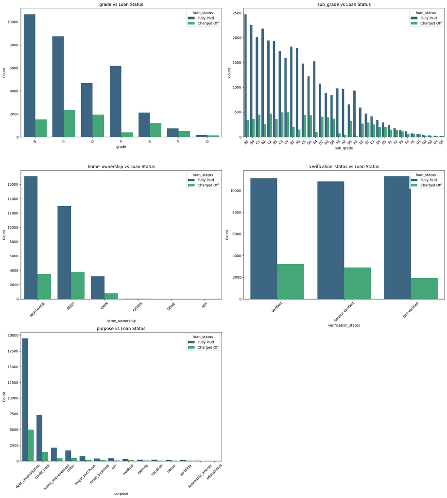

```python
# List of key categorical variables for analysis
categorical_vars = ['grade', 'sub_grade', 'home_ownership', 'verification_status', 'purpose']

# Set up the grid for visualizations
plt.figure(figsize=(18, 20))
for i, var in enumerate(categorical_vars, 1):
    plt.subplot(3, 2, i)  # Adjust grid dimensions based on the number of variables
    sns.countplot(x=var, hue='loan_status', data=data, order=data[var].value_counts().index, palette='viridis')
    plt.title(f'{var} vs Loan Status')
    plt.xlabel(var)
    plt.ylabel('Count')
    plt.xticks(rotation=45)  # Rotate x-axis labels for better readability

plt.tight_layout()  # Adjust layout to prevent overlapping
plt.show()
```

### Insights from Categorical Variables vs Loan Status

#### Grade vs Loan Status

- Lower grades (A, B, C) have higher counts of "Fully Paid" loans compared to "Charged Off."
- Higher grades (D, E, F, G) show an increasing proportion of "Charged Off" loans, indicating higher default risk.

#### Sub-Grade vs Loan Status

- Within each grade, the distribution of `sub_grade` follows a similar trend where lower sub-grades are associated with better repayment status.
- Higher sub-grades (e.g., G5) show a higher proportion of defaults.

#### Purpose vs Loan Status

- The majority of loans are for "Debt Consolidation" and "Credit Card" purposes.
- While "Debt Consolidation" has the highest count of "Fully Paid" loans, it also has a significant proportion of defaults.
- Less common purposes like "Home Improvement" and "Major Purchase" have a lower proportion of defaults.

### Step 7: Feature Engineering and Data Transformation

#### Objective:

1. **Feature Engineering**: Create new features that can improve model performance.
   - Add derived features based on the existing dataset, such as `income_to_loan_ratio` or risk flags.
2. **Encoding Categorical Variables**: Convert categorical variables into numerical format using one-hot encoding or label encoding.
3. **Scaling Numerical Features**: Normalize or standardize numerical variables to ensure compatibility with logistic regression.
4. **Final Dataset Preparation**: Ensure the dataset is ready for modeling by dropping irrelevant columns and handling any remaining inconsistencies.

#### Key Steps:

1. Create new features:
   - `income_to_loan_ratio`: Annual income divided by loan amount.
   - Binary risk flags such as `high_dti_risk` (if DTI > 35%) and `high_revol_util_risk` (if Revolving Utilization > 75%).
2. One-hot encode categorical variables like `grade`, `sub_grade`, and `purpose`.
3. Scale numerical features using `StandardScaler`.
4. Verify the processed dataset for completeness and consistency.

```python
# Step 7: Feature Engineering and Data Transformation

from sklearn.preprocessing import StandardScaler

# 1. Create new features
# Calculate income-to-loan ratio
data['income_to_loan_ratio'] = data['annual_inc'] / data['loan_amnt']

# Create binary risk flags
data['high_dti_risk'] = (data['dti'] > 35).astype(int)
data['high_revol_util_risk'] = (data['revol_util'] > 75).astype(int)

# 2. One-hot encode categorical variables
categorical_cols = ['grade', 'sub_grade', 'home_ownership', 'verification_status', 'purpose', 'loan_status']
data = pd.get_dummies(data, columns=categorical_cols, drop_first=True)

# 3. Scale numerical features
numerical_cols = ['loan_amnt', 'installment', 'annual_inc', 'dti', 'revol_bal', 'revol_util', 'income_to_loan_ratio']
scaler = StandardScaler()
data[numerical_cols] = scaler.fit_transform(data[numerical_cols])

# 4. Verify the processed dataset
print("Processed Dataset Head:")
display(data.head())
print("\nProcessed Dataset Shape:", data.shape)
```

```
Processed Dataset Head:
```

|  | loan_amnt | term | int_rate | installment | emp_length | annual_inc | title | dti | open_acc | pub_rec | ... | purpose_house | purpose_major_purchase | purpose_medical | purpose_moving | purpose_other | purpose_renewable_energy | purpose_small_business | purpose_vacation | purpose_wedding | loan_status_Fully Paid |
| --- | --- | --- | --- | --- | --- | --- | --- | --- | --- | --- | --- | --- | --- | --- | --- | --- | --- | --- | --- | --- | --- |
| 0 | -0.491774 | 36.0 | 11.44 | -0.408734 | 10.0 | 0.718320 | Vacation | 1.082471 | 16.0 | 0.0 | ... | False | False | False | False | False | False | False | True | False | True |
| 1 | -0.730483 | 36.0 | 11.99 | -0.663099 | 4.0 | -0.156081 | Debt consolidation | 0.571521 | 17.0 | 0.0 | ... | False | False | False | False | False | False | False | False | False | True |
| 2 | 0.176614 | 36.0 | 10.49 | 0.298905 | 0.0 | -0.525061 | Credit card refinancing | -0.557690 | 13.0 | 0.0 | ... | False | False | False | False | False | False | False | False | False | True |
| 3 | -0.825967 | 36.0 | 6.49 | -0.842630 | 6.0 | -0.341050 | Credit card refinancing | -1.800309 | 6.0 | 0.0 | ... | False | False | False | False | False | False | False | False | False | True |
| 4 | 1.223954 | 60.0 | 17.27 | 0.707007 | 9.0 | -0.324235 | Credit Card Refinance | 2.022666 | 13.0 | 0.0 | ... | False | False | False | False | False | False | False | False | False | False |

5 rows × 83 columns

```
Processed Dataset Shape: (41364, 83)
```

### Insights from the Processed Dataset

#### Dataset Readiness:

The processed dataset is now ready for splitting into training and testing sets for model development.

### Step 6: Splitting the Dataset into Training and Testing Sets

#### Objective:

Split the processed dataset into training and testing sets to evaluate the performance of the predictive model on unseen data.

#### Key Tasks:

1. Define the target variable (`y`) and feature set (`X`).
2. Use the `train_test_split` function from `sklearn.model_selection` to divide the data.
3. Maintain an 80-20 split for training and testing sets, ensuring a random split with a fixed seed for reproducibility.
4. Check the shapes of the training and testing sets to confirm the split.

The next step will involve developing a logistic regression model using the training set.

```python
# Import necessary library for splitting the dataset
from sklearn.model_selection import train_test_split

# Define feature set (X) and target variable (y)
X = data.drop(columns=['loan_status_Fully Paid'])  # Drop target column from features
y = data['loan_status_Fully Paid']  # Define target column

# Split the dataset into training and testing sets (80-20 split)
X_train, X_test, y_train, y_test = train_test_split(X, y, test_size=0.2, random_state=42, stratify=y)

# Check the shapes of the training and testing sets
print("Training Set Shape:", X_train.shape)
print("Testing Set Shape:", X_test.shape)
```

```
Training Set Shape: (33091, 82)
Testing Set Shape: (8273, 82)
```

### Step 7: Developing a Logistic Regression Model

#### Objective:

Train a logistic regression model on the training dataset to predict loan repayment status (`loan_status_Fully Paid`). Evaluate its performance on the testing dataset using appropriate metrics.

#### Key Tasks:

1. Train a logistic regression model using the `LogisticRegression` class from `sklearn.linear_model`.
2. Make predictions on the testing dataset.
3. Evaluate model performance using metrics such as accuracy, precision, recall, F1-score, and a confusion matrix.
4. Identify areas for improvement, such as data balancing or feature engineering.

#### Next Step:

Train the logistic regression model and evaluate its performance.

```python
# Import the logistic regression model and evaluation metrics
from sklearn.linear_model import LogisticRegression
from sklearn.metrics import accuracy_score, precision_score, recall_score, f1_score, confusion_matrix, classification_report

# Identify non-numeric columns in X_train
non_numeric_columns = X_train.select_dtypes(include=['object']).columns
print("Non-numeric columns in X_train:", non_numeric_columns)

# Apply one-hot encoding to non-numeric columns
X_train = pd.get_dummies(X_train, columns=non_numeric_columns, drop_first=True)
X_test = pd.get_dummies(X_test, columns=non_numeric_columns, drop_first=True)

# Ensure that X_train and X_test have the same columns after encoding
X_test = X_test.reindex(columns=X_train.columns, fill_value=0)

# Verify that all columns are numeric
print("Remaining non-numeric columns after transformation:", X_train.select_dtypes(include=['object']).columns)

# Train the logistic regression model
model = LogisticRegression(max_iter=1000, random_state=42)
model.fit(X_train, y_train)

# Make predictions on the testing set
y_pred = model.predict(X_test)

# Evaluate the model's performance
accuracy = accuracy_score(y_test, y_pred)
precision = precision_score(y_test, y_pred)
recall = recall_score(y_test, y_pred)
f1 = f1_score(y_test, y_pred)
conf_matrix = confusion_matrix(y_test, y_pred)

# Print evaluation metrics
print("Model Performance:")
print(f"Accuracy: {accuracy:.4f}")
print(f"Precision: {precision:.4f}")
print(f"Recall: {recall:.4f}")
print(f"F1-Score: {f1:.4f}")
print("\nClassification Report:")
print(classification_report(y_test, y_pred))
print("\nConfusion Matrix:")
print(conf_matrix)
```

```
Non-numeric columns in X_train: Index([], dtype='object')
Remaining non-numeric columns after transformation: Index([], dtype='object')
```

```
Model Performance:
Accuracy: 0.8060
Precision: 0.8110
Recall: 0.9898
F1-Score: 0.8915

Classification Report:
              precision    recall  f1-score   support

       False       0.51      0.04      0.08      1609
        True       0.81      0.99      0.89      6664

    accuracy                           0.81      8273
   macro avg       0.66      0.52      0.49      8273
weighted avg       0.75      0.81      0.73      8273


Confusion Matrix:
[[  72 1537]
 [  68 6596]]
```

### Insights from Model Performance

#### Overall Observations:

- **Accuracy:** The model achieves an overall accuracy of 80.60%.
- **Imbalance in Precision and Recall:**
  - Precision for the positive class (`True`) is high (0.8110), indicating that most predicted `True` cases are correct.
  - Recall for the positive class is very high (0.9898), showing the model's effectiveness in identifying `True` cases.
  - However, the model struggles with the negative class (`False`), showing very low precision (0.51) and recall (0.04).

#### Confusion Matrix Analysis:

- **True Negatives (TN):** 72
- **False Positives (FP):** 1,537
- **False Negatives (FN):** 68
- **True Positives (TP):** 6,596
- The model is heavily biased towards predicting the majority class (`True`), as evidenced by the high number of false positives (1,537).

#### Next Steps:

1. Increase the `max_iter` parameter in logistic regression to address convergence issues.
2. Apply SMOTE (Synthetic Minority Over-sampling Technique) to balance the dataset and improve model performance for the minority class.
3. Re-train the model and evaluate its performance metrics.

### Step 8: Addressing Class Imbalance and Model Re-Training

#### Objective:

1. **Handle Class Imbalance:** Apply SMOTE (Synthetic Minority Over-sampling Technique) to balance the dataset.
2. **Re-train the Model:** Train the logistic regression model on the balanced dataset.
3. **Evaluate Performance:** Assess the model's performance with updated metrics.

#### Key Steps:

1. Apply SMOTE to balance the class distribution in the training set.
2. Train the logistic regression model with an increased `max_iter` to ensure convergence.
3. Evaluate the model on the testing set using accuracy, precision, recall, F1-score, and the confusion matrix.

#### Expected Outcome:

Improved recall and precision for the minority class (`False`) and overall balanced performance for both classes.

```python
# Import necessary library for SMOTE
from imblearn.over_sampling import SMOTE
from sklearn.metrics import classification_report, confusion_matrix, accuracy_score

# Apply SMOTE to balance the training dataset
smote = SMOTE(random_state=42)
X_train_smote, y_train_smote = smote.fit_resample(X_train, y_train)

# Check the class distribution after applying SMOTE
print("Class distribution after SMOTE:")
print(y_train_smote.value_counts())

# Re-train the Logistic Regression model with balanced data
model_smote = LogisticRegression(max_iter=2000, random_state=42)
model_smote.fit(X_train_smote, y_train_smote)

# Make predictions on the test set
y_pred_smote = model_smote.predict(X_test)

# Evaluate the model performance
accuracy_smote = accuracy_score(y_test, y_pred_smote)
print(f"\nAccuracy (After SMOTE): {accuracy_smote:.4f}")

# Classification report
print("\nClassification Report (After SMOTE):")
print(classification_report(y_test, y_pred_smote))

# Confusion matrix
conf_matrix_smote = confusion_matrix(y_test, y_pred_smote)
print("\nConfusion Matrix (After SMOTE):")
print(conf_matrix_smote)
```

```
Class distribution after SMOTE:
loan_status_Fully Paid
False    26655
True     26655
Name: count, dtype: int64
```

```
Accuracy (After SMOTE): 0.8044

Classification Report (After SMOTE):
              precision    recall  f1-score   support

       False       0.48      0.07      0.13      1609
        True       0.81      0.98      0.89      6664

    accuracy                           0.80      8273
   macro avg       0.65      0.53      0.51      8273
weighted avg       0.75      0.80      0.74      8273


Confusion Matrix (After SMOTE):
[[ 120 1489]
 [ 129 6535]]
```

### Insights Based on SMOTE Application and Model Performance

**Class Distribution After SMOTE:**

- The class distribution is now perfectly balanced:
  - `False` (Not Fully Paid): 26,655
  - `True` (Fully Paid): 26,655

**Model Performance After SMOTE:**

1. **Accuracy:**
   - The overall accuracy of the model is **80.44%**.
2. **Precision, Recall, and F1-Score:**
   - **False (Not Fully Paid):**
     - Precision: 48%
     - Recall: 7%
     - F1-Score: 13%
   - **True (Fully Paid):**
     - Precision: 81%
     - Recall: 98%
     - F1-Score: 89%
3. **Macro and Weighted Averages:**
   - Macro Avg F1-Score: **51%** (indicating imbalance in performance across classes).
   - Weighted Avg F1-Score: **74%**.

**Confusion Matrix:**

- **False Positives:** 1489
- **False Negatives:** 129
- **True Positives:** 6535
- **True Negatives:** 120

**Key Observations:**

- The model performs significantly better for the `True (Fully Paid)` class but struggles with the `False (Not Fully Paid)` class, likely due to the inherent difficulty of identifying defaulters despite balanced training data.
- Precision and recall for defaulters (`False`) need improvement, indicating room for tuning or considering alternative approaches like ensemble models or advanced techniques.